# Kamień milowy 2

Agata Makarewicz, Martyna Majchrzak, Renata Rólkiewicz

24 03 2020

## Wprowadzenie

Poniższa analiza eksploracyjna dotyczy [zbioru danych](https://datahub.io/machine-learning/breast-w#data-cl) zawierającego informacje na temat przypadków raka piersi u kobiet z Wisconsin, USA.

Tab.1. Fragment ramki danych

| Clump_Thickness | Cell_Size_Uniformity | Cell_Shape_Uniformity | Marginal_Adhesion | Single_Epi_Cell_Size | Bare_Nuclei | Bland_Chromatin | Normal_Nucleoli | Mitoses | Class |
| --- | --- | --- | --- | --- | --- | --- | --- | --- | --- |
| 5 | 1 | 1 | 1 | 2 | 1 | 3 | 1 | 1 | benign |
| 5 | 4 | 4 | 5 | 7 | 10 | 3 | 2 | 1 | benign |
| 3 | 1 | 1 | 1 | 2 | 2 | 3 | 1 | 1 | benign |
| 6 | 8 | 8 | 1 | 3 | 4 | 3 | 7 | 1 | benign |
| 4 | 1 | 1 | 3 | 2 | 1 | 3 | 1 | 1 | benign |
| 8 | 10 | 10 | 8 | 7 | 10 | 9 | 7 | 1 | malignant |

Zobaczmy najpierw co oznaczają poszczególne zmienne:

- 1 - Clump_Thickness - grubość grudki, określa czy komórki są jedno- / wielowarstwowe
- 2 - Cell_Size_Uniformity - regularność/jednorodność wielkości komórek
- 3 - Cell_Shape_Uniformity - regularność/jednorodność kształtu komórek
- 4 - Marginal_Adhesion - zrosty na brzegach
- 5 - Single_Epi_Cell_Size - epithelial cells, czy komórki nabłonkowe są znacznie powiększone
- 6 - Bare_Nuclei - proporcja komórek nieotoczonych cytoplazmą do tych, które są nią otoczone
- 7 - Bland_Chromatin - jednolitość tekstury jądra (od drobnego do grubego)
- 8 - Normal_Nucleoli - normalne jąderka (?) określa czy są małe i ledwo widoczne czy duże
- 9 - Mitoses - mitozy
- 10 - Class - czy rak jest łagodny(benign) czy złośliwy(malignant)

Tab.2. Statystyki danych

|  | Clump_Thickness | Cell_Size_Uniformity | Cell_Shape_Uniformity | Marginal_Adhesion | Single_Epi_Cell_Size | Bare_Nuclei | Bland_Chromatin | Normal_Nucleoli | Mitoses | Class |
| --- | --- | --- | --- | --- | --- | --- | --- | --- | --- | --- |
|  | Min. : 1.000 | Min. : 1.000 | Min. : 1.000 | Min. : 1.000 | Min. : 1.000 | Min. : 1.000 | Min. : 1.000 | Min. : 1.000 | Min. : 1.000 | benign :458 |
|  | 1st Qu.: 2.000 | 1st Qu.: 1.000 | 1st Qu.: 1.000 | 1st Qu.: 1.000 | 1st Qu.: 2.000 | 1st Qu.: 1.000 | 1st Qu.: 2.000 | 1st Qu.: 1.000 | 1st Qu.: 1.000 | malignant:241 |
|  | Median : 4.000 | Median : 1.000 | Median : 1.000 | Median : 1.000 | Median : 2.000 | Median : 1.000 | Median : 3.000 | Median : 1.000 | Median : 1.000 | NA |
|  | Mean : 4.418 | Mean : 3.134 | Mean : 3.207 | Mean : 2.807 | Mean : 3.216 | Mean : 3.545 | Mean : 3.438 | Mean : 2.867 | Mean : 1.589 | NA |
|  | 3rd Qu.: 6.000 | 3rd Qu.: 5.000 | 3rd Qu.: 5.000 | 3rd Qu.: 4.000 | 3rd Qu.: 4.000 | 3rd Qu.: 6.000 | 3rd Qu.: 5.000 | 3rd Qu.: 4.000 | 3rd Qu.: 1.000 | NA |
|  | Max. :10.000 | Max. :10.000 | Max. :10.000 | Max. :10.000 | Max. :10.000 | Max. :10.000 | Max. :10.000 | Max. :10.000 | Max. :10.000 | NA |
|  | NA | NA | NA | NA | NA | NA’s :16 | NA | NA | NA | NA |

## Rozkłady zmiennych

Zacznijmy od sprawdzenia struktury naszych danych.

```
## 'data.frame':    699 obs. of  10 variables:
##  $ Clump_Thickness      : int  5 5 3 6 4 8 1 2 2 4 ...
##  $ Cell_Size_Uniformity : int  1 4 1 8 1 10 1 1 1 2 ...
##  $ Cell_Shape_Uniformity: int  1 4 1 8 1 10 1 2 1 1 ...
##  $ Marginal_Adhesion    : int  1 5 1 1 3 8 1 1 1 1 ...
##  $ Single_Epi_Cell_Size : int  2 7 2 3 2 7 2 2 2 2 ...
##  $ Bare_Nuclei          : int  1 10 2 4 1 10 10 1 1 1 ...
##  $ Bland_Chromatin      : int  3 3 3 3 3 9 3 3 1 2 ...
##  $ Normal_Nucleoli      : int  1 2 1 7 1 7 1 1 1 1 ...
##  $ Mitoses              : int  1 1 1 1 1 1 1 1 5 1 ...
##  $ Class                : Factor w/ 2 levels "benign","malignant": 1 1 1 1 1 2 1 1 1 1 ...
```

Jak widać, większość stanowią zmienne dyskretne, zobaczmy zatem ich rozkłady.

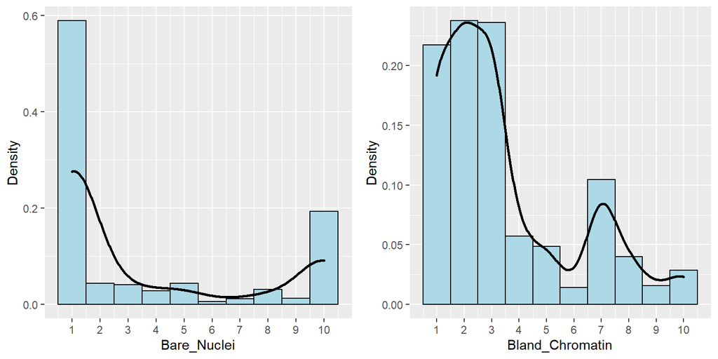

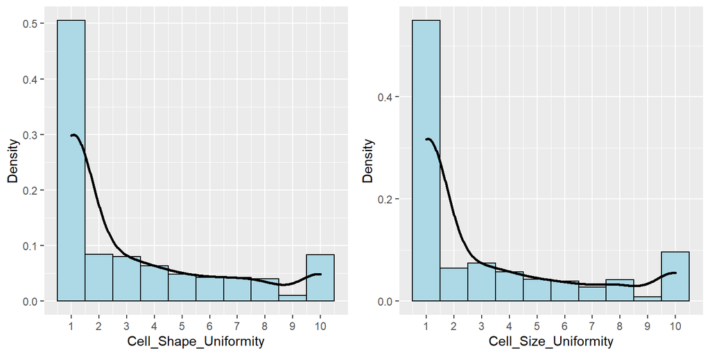

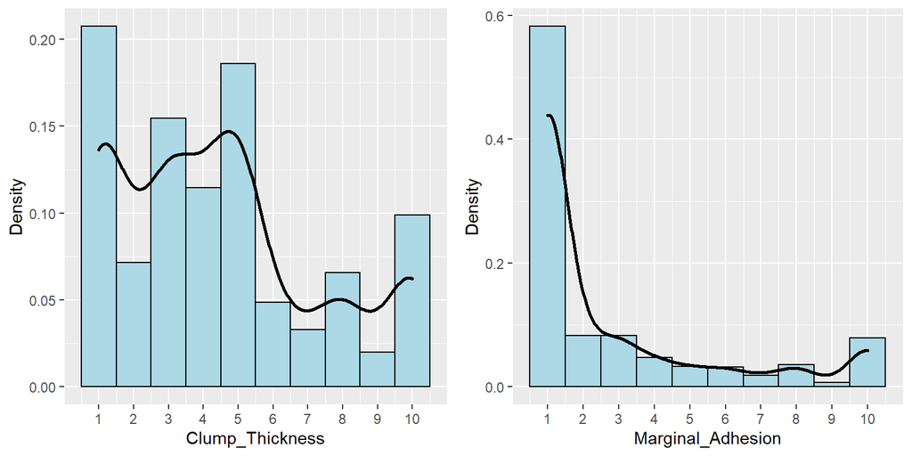

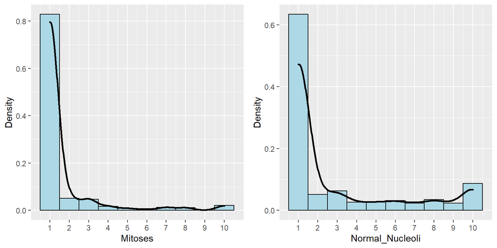

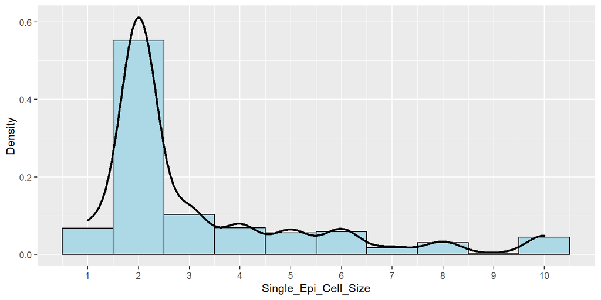

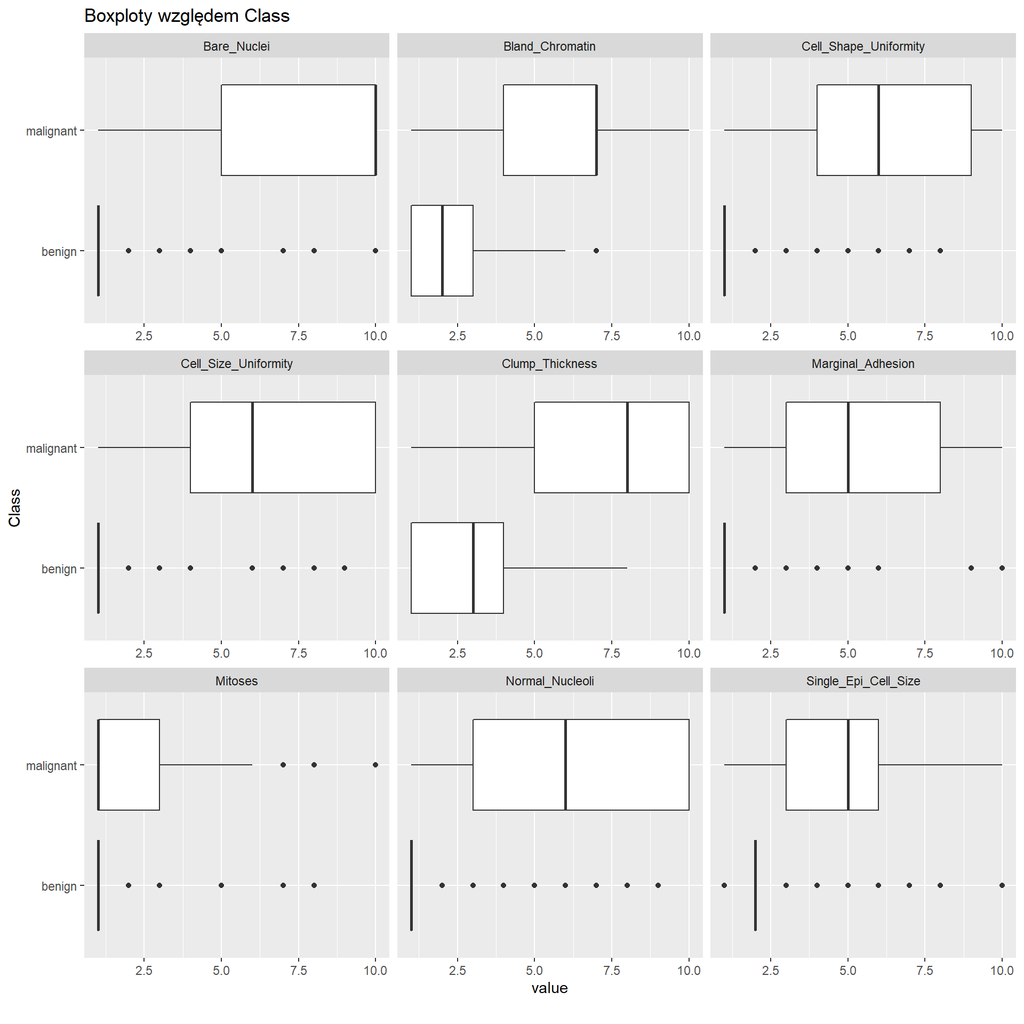

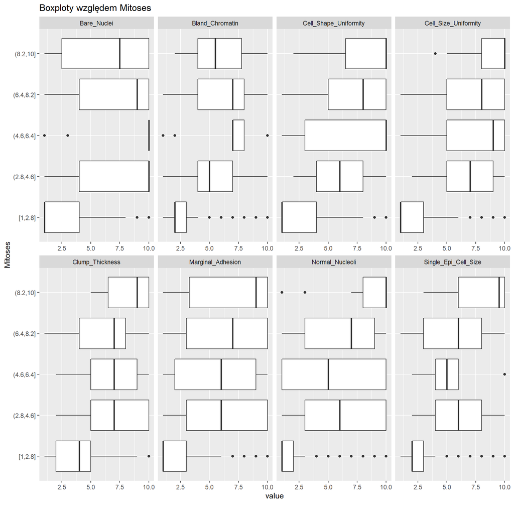

Jedyną zmienną kategoryczą w naszych danych jest nasza zmienna celu, czyli Class.

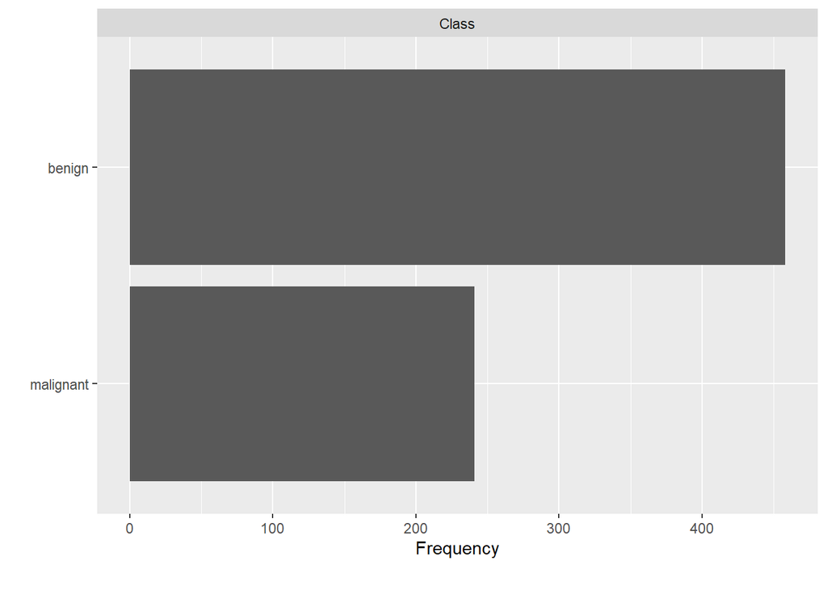

Widzimy, że przypadków złośliwych jest o połowę mniej niż przypadków łagodnych. Stanowią one około 1/3 wszystkich rekordów.

## Braki danych

```
## # A tibble: 10 x 3
##    variable              n_miss pct_miss
##    <chr>                  <int>    <dbl>
##  1 Bare_Nuclei               16     2.29
##  2 Clump_Thickness            0     0
##  3 Cell_Size_Uniformity       0     0
##  4 Cell_Shape_Uniformity      0     0
##  5 Marginal_Adhesion          0     0
##  6 Single_Epi_Cell_Size       0     0
##  7 Bland_Chromatin            0     0
##  8 Normal_Nucleoli            0     0
##  9 Mitoses                    0     0
## 10 Class                      0     0
```

Jak widać, w naszych danych znajduje się 16 rekordów z brakującymi danymi w kolumnie Bare_Nuclei. Zajmiemy się nimi później, przy trenowaniu modeli.

## Korelacje między zmiennymi

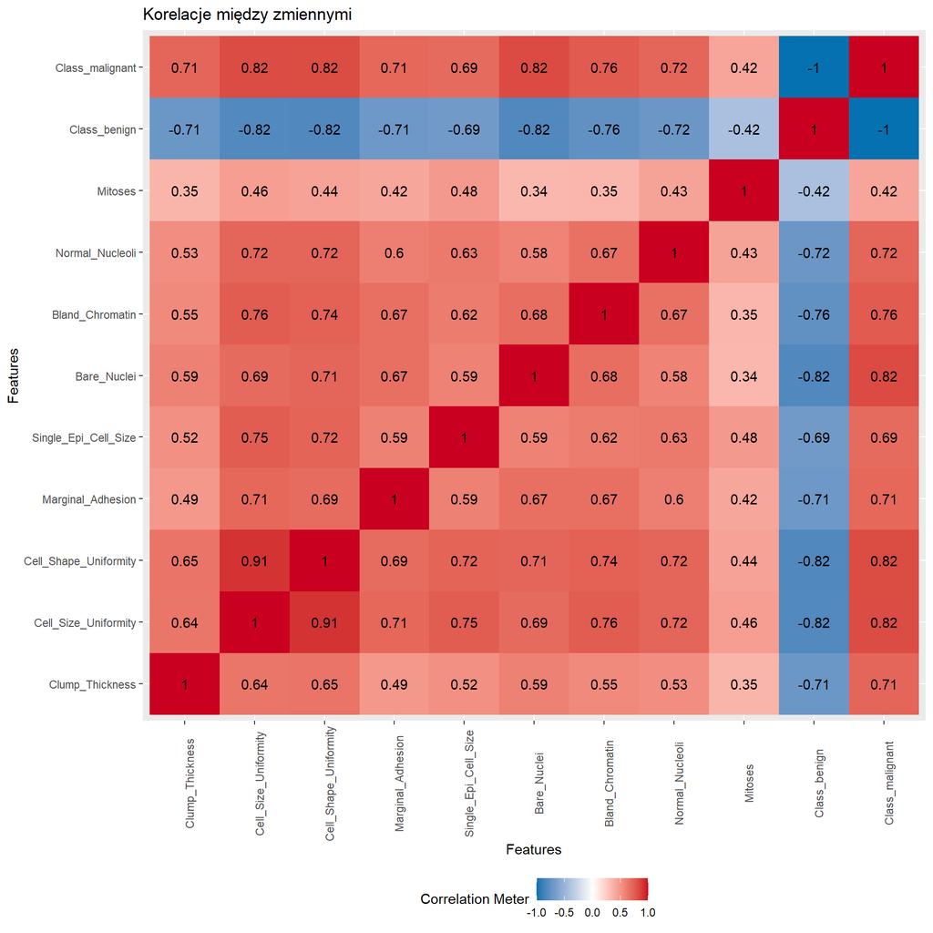

## Zależności między zmiennymi

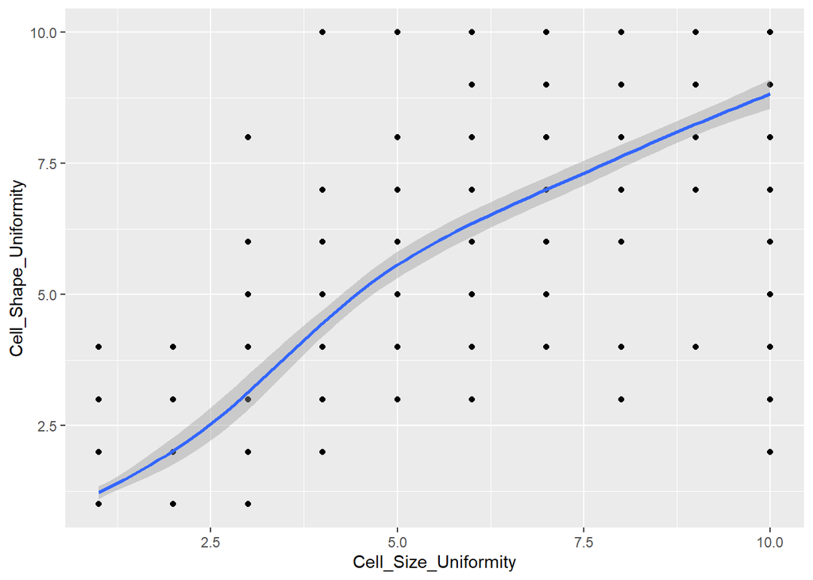

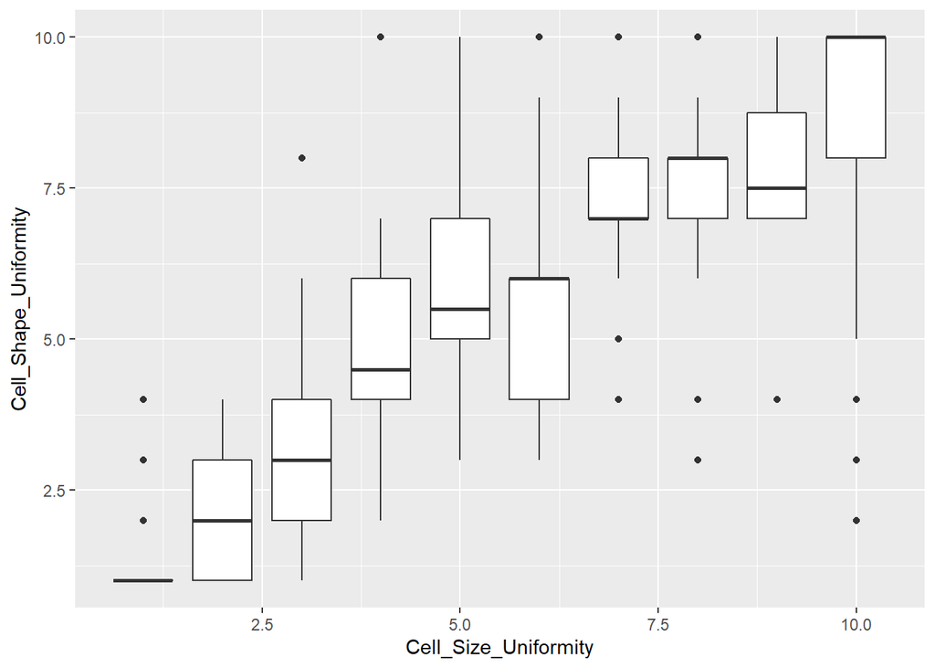

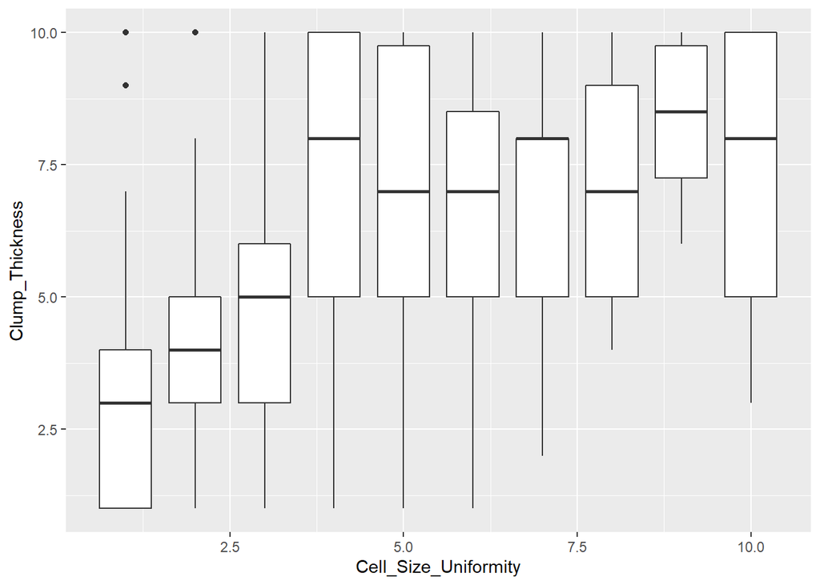

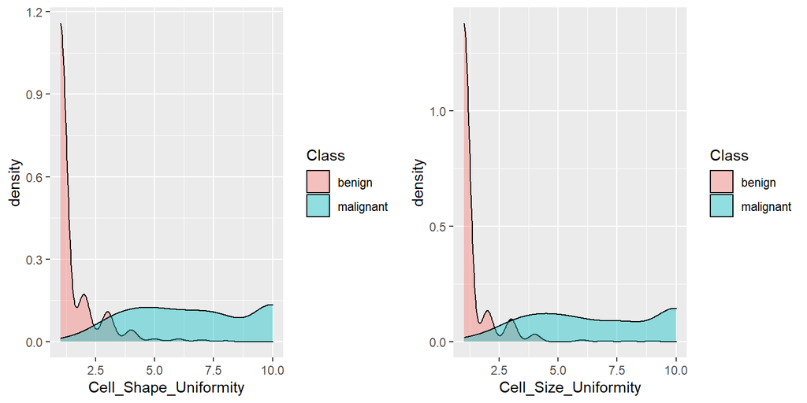

## PCA - Principal Component Analysis

```r
data_pca <- prcomp(na.omit(data_breast[,-10]), scale. = TRUE, center = TRUE)
summary(data_pca)
```

```
## Importance of components:
##                           PC1     PC2     PC3     PC4     PC5     PC6     PC7
## Standard deviation     2.4289 0.88088 0.73434 0.67796 0.61667 0.54943 0.54259
## Proportion of Variance 0.6555 0.08622 0.05992 0.05107 0.04225 0.03354 0.03271
## Cumulative Proportion  0.6555 0.74172 0.80163 0.85270 0.89496 0.92850 0.96121
##                            PC8     PC9
## Standard deviation     0.51062 0.29729
## Proportion of Variance 0.02897 0.00982
## Cumulative Proportion  0.99018 1.00000
```

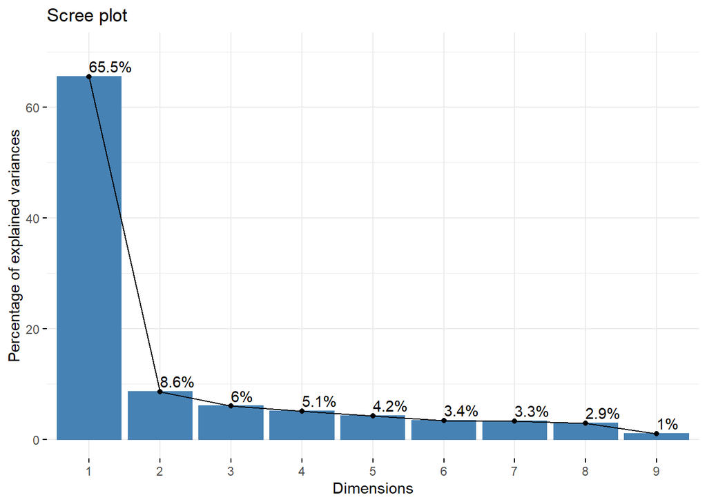

```r
fviz_screeplot(data_pca, addlabels = TRUE, ylim = c(0, 70))
```

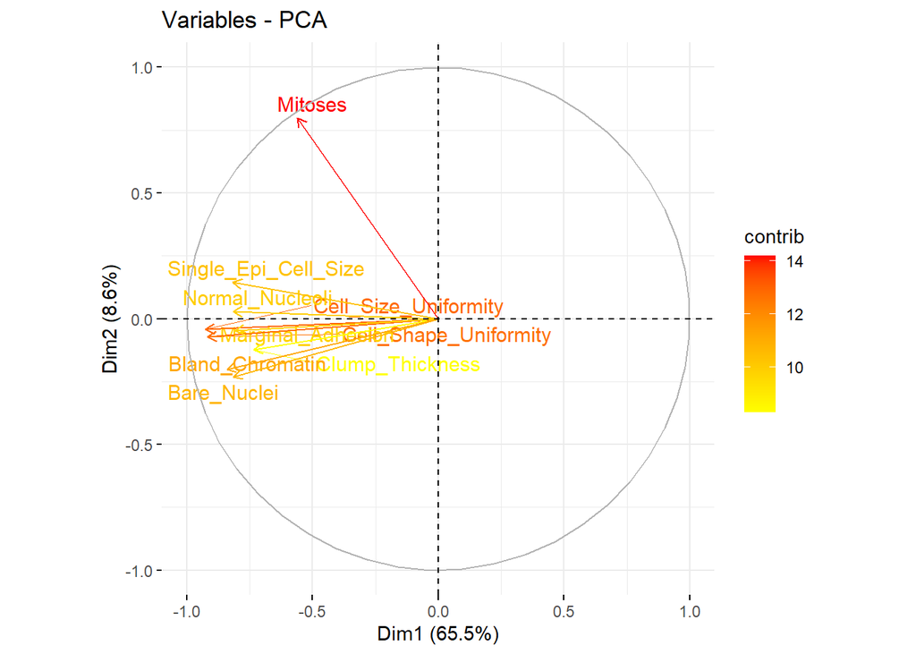

```r
# Korelacja zmiennych i ich wplyw na glowne skladowe
fviz_pca_var(data_pca,
             col.var = "contrib",
             gradient.cols = c("#FFFF00", "orange", "red"),
             repel = TRUE)
```

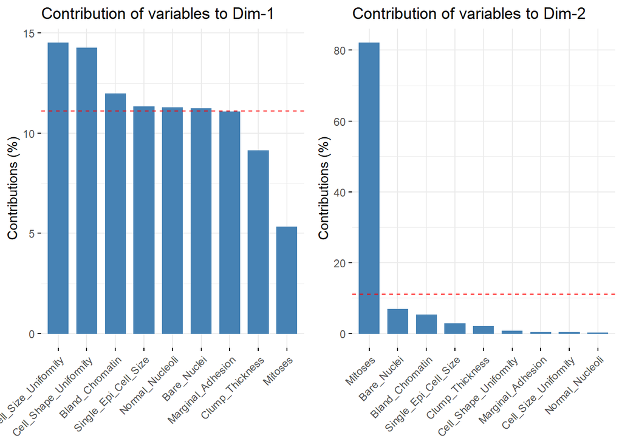

```r
c1 <- fviz_contrib(data_pca, choice = "var", axes = 1, top = 10)
c2 <- fviz_contrib(data_pca, choice = "var", axes = 2, top = 10)
grid.arrange(c1, c2, ncol=2)
```

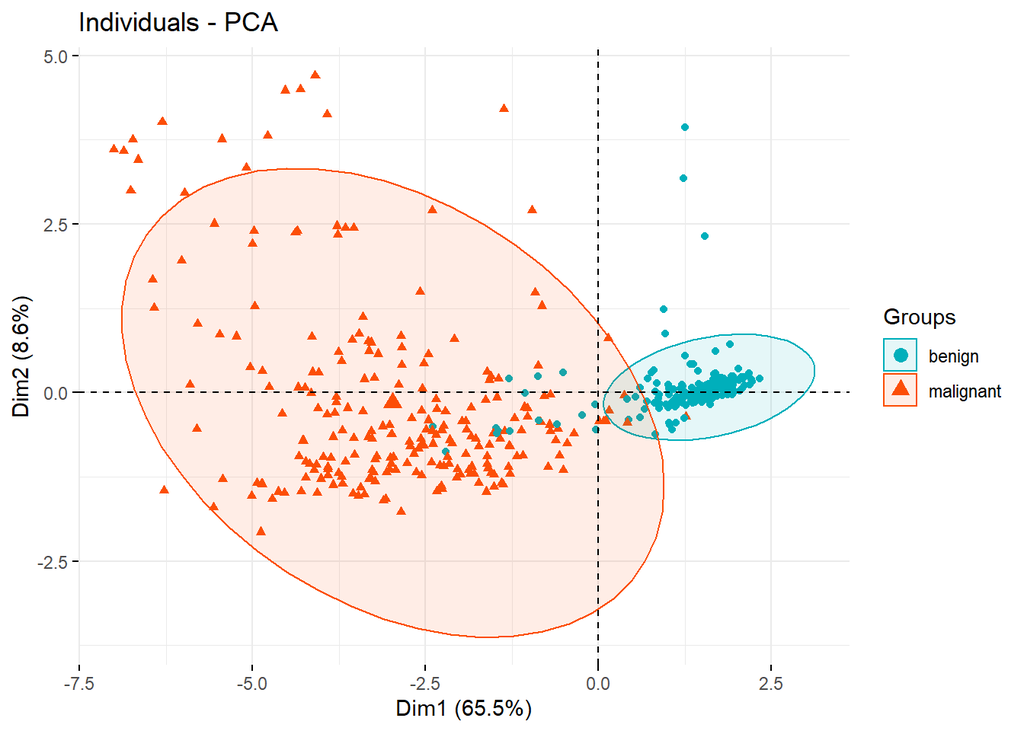

```r
fviz_pca_ind(data_pca,
             label = "none", #hide individual labels
             habillage = na.omit(data_breast)$Class, #color by groups
             palette = c("#00AFBB","#FC4E07"),
             addEllipses = TRUE #concentration ellipses
)
```

## Podział na zbiór treningowy i testowy oraz imputacja danych

Zaczynamy od podzielenia naszego zbioru danych na treningowy i testowy. Pierwszy z nich składa się z 80% losowo wybranych rekordów, drugi z pozostałych 20%.

Na tak podzielonych danych zastosujemy dwie różne metody imputacji.

### Metoda 1 - usunięcie rekordów zawierających NA

```r
# usunięcie rekordów zawierających NA
data_train1 <- na.omit(data_train)
data_test1 <- na.omit(data_test)

task1 <- TaskClassif$new(id = "breast_naomit", backend = data_train1, target = "Class")
```

### Metoda 2 - uzupełnienie brakujących danych za pomocą funkcji mice

```r
# Uzywamy metody pmm

# Zbiór treningowy
na <- subset(data_train, is.na(data_train$Bare_Nuclei))
row_id <- row.names(na)
# Usuwamy tymczasowo target, zeby nie było przecieku danych
imp <- mice(data_train[,-10], method = "pmm", m=5, maxit =5, seed = 1)
data_train2 <- complete(imp)
# Dołączamy z powrotem target
data_train2 <- cbind(data_train2, data_train$Class)
colnames(data_train2)[10] <- "Class"

# Zbiór testowy
na <- subset(data_test, is.na(data_test$Bare_Nuclei))
row_id <- row.names(na)
# Usuwamy tymczasowo target
imp <- mice(data_test[,-10], method = "pmm", m=5, maxit =5, seed = 1)
data_test2 <- complete(imp)
# Dołączamy z powrotem target
data_test2<-cbind(data_test2, data_test$Class)
colnames(data_test2)[10] <- "Class"

task2 <- TaskClassif$new(id = "breast_imp", backend = data_train2, target = "Class")
```

## Metody klasyfikacji

Wytrenujemy na obu zbiorach danych po 5 modeli:

1. SVM - Support Vector Machine
2. RF - Random Forest
3. BN - Bayesian Networks
4. LDA - Linear Discriminal Analysis
5. RPART - Recursive Partitioning and Regression Trees

Następnie przeprowadzimy kroswalidację na zbiorze treningowym (dzieląc na 5 części) oraz predykcję na testowym.

### SVM - Support Vector Machine

#### Metoda 1

```
## INFO  [07:11:51.736] Applying learner 'classif.svm' on task 'breast_naomit' (iter 1/5)
## INFO  [07:11:51.829] Applying learner 'classif.svm' on task 'breast_naomit' (iter 2/5)
## INFO  [07:11:51.881] Applying learner 'classif.svm' on task 'breast_naomit' (iter 3/5)
## INFO  [07:11:51.923] Applying learner 'classif.svm' on task 'breast_naomit' (iter 4/5)
## INFO  [07:11:51.971] Applying learner 'classif.svm' on task 'breast_naomit' (iter 5/5)
```

```
##    row_id     truth  response  prob.benign prob.malignant
## 1:      1    benign malignant 0.0532287279    0.946771272
## 2:      2    benign    benign 0.9933851921    0.006614808
## 3:      3 malignant malignant 0.2326096909    0.767390309
## 4:      4    benign    benign 0.9989668366    0.001033163
## 5:      5 malignant malignant 0.0008062154    0.999193785
## 6:      6 malignant malignant 0.0002385159    0.999761484
```

```
##            truth
## response    benign malignant
##   benign        82         3
##   malignant      4        48
```

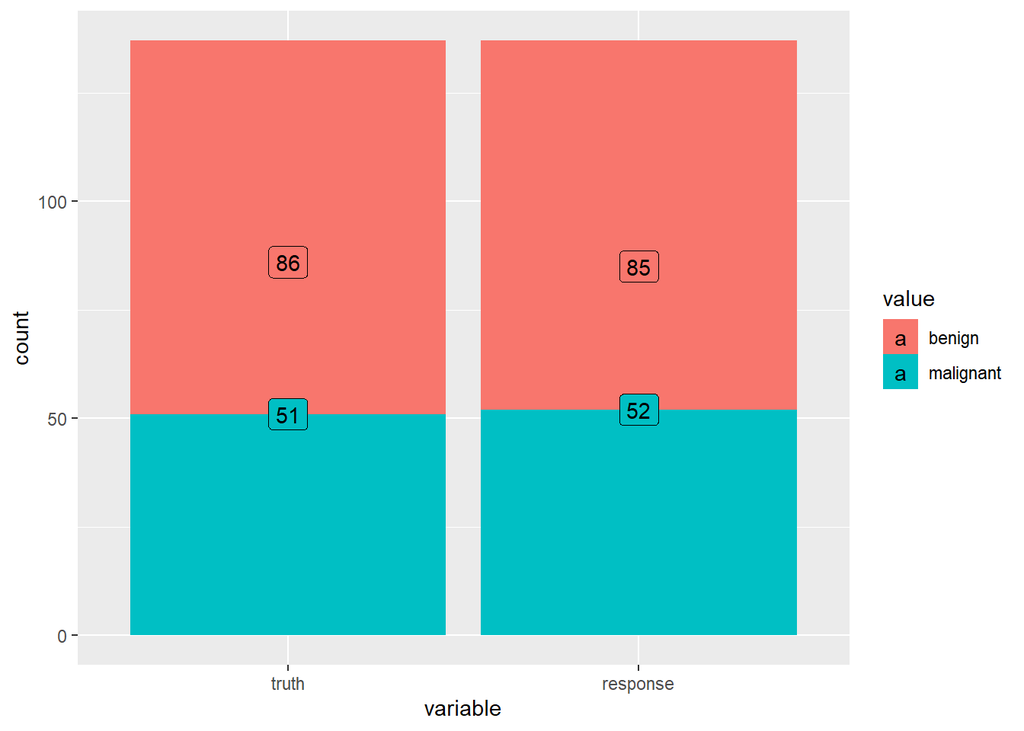

#### Metoda 2 - pmm

```
## INFO  [07:11:52.725] Applying learner 'classif.svm' on task 'breast_imp' (iter 1/5)
## INFO  [07:11:52.770] Applying learner 'classif.svm' on task 'breast_imp' (iter 2/5)
## INFO  [07:11:52.828] Applying learner 'classif.svm' on task 'breast_imp' (iter 3/5)
## INFO  [07:11:52.883] Applying learner 'classif.svm' on task 'breast_imp' (iter 4/5)
## INFO  [07:11:52.924] Applying learner 'classif.svm' on task 'breast_imp' (iter 5/5)
```

```
##    row_id     truth  response prob.benign prob.malignant
## 1:      1    benign malignant 0.141128376    0.858871624
## 2:      2    benign    benign 0.984969279    0.015030721
## 3:      3 malignant malignant 0.013386905    0.986613095
## 4:      4 malignant malignant 0.348977751    0.651022249
## 5:      5    benign    benign 0.997300521    0.002699479
## 6:      6 malignant malignant 0.004461913    0.995538087
```

```
##            truth
## response    benign malignant
##   benign        84         3
##   malignant      4        49
```

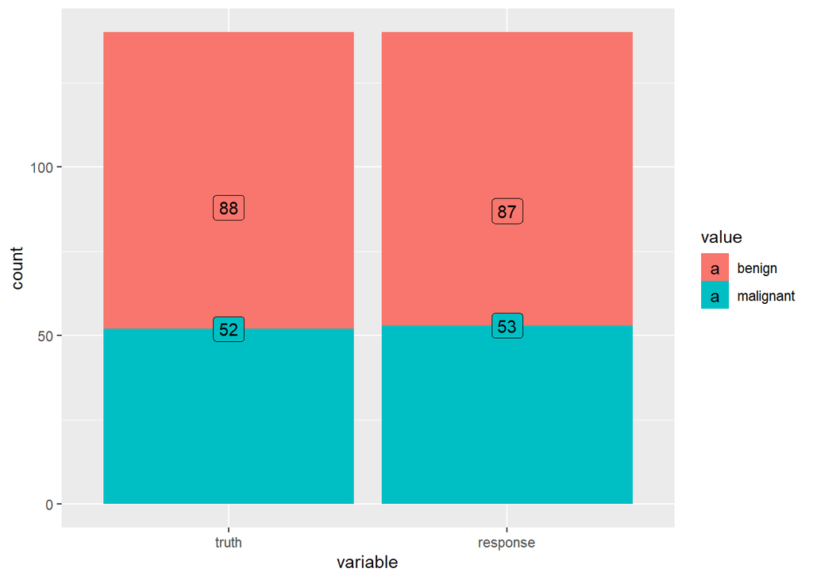

### RF - Random Forest

#### Metoda 1

```
## INFO  [07:11:53.782] Applying learner 'classif.ranger' on task 'breast_naomit' (iter 1/5)
## INFO  [07:11:53.875] Applying learner 'classif.ranger' on task 'breast_naomit' (iter 2/5)
## INFO  [07:11:53.964] Applying learner 'classif.ranger' on task 'breast_naomit' (iter 3/5)
## INFO  [07:11:54.061] Applying learner 'classif.ranger' on task 'breast_naomit' (iter 4/5)
## INFO  [07:11:54.149] Applying learner 'classif.ranger' on task 'breast_naomit' (iter 5/5)
```

```
##    row_id     truth  response prob.benign prob.malignant
## 1:      1    benign malignant 0.175647619      0.8243524
## 2:      2    benign    benign 1.000000000      0.0000000
## 3:      3 malignant malignant 0.373693651      0.6263063
## 4:      4    benign    benign 1.000000000      0.0000000
## 5:      5 malignant malignant 0.010894444      0.9891056
## 6:      6 malignant malignant 0.009235714      0.9907643
```

```
##            truth
## response    benign malignant
##   benign        83         2
##   malignant      3        49
```

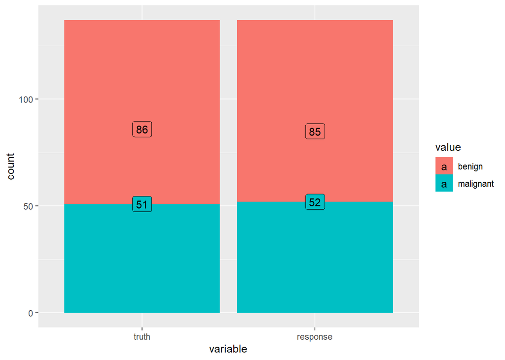

#### Metoda 2

```
## INFO  [07:11:55.069] Applying learner 'classif.ranger' on task 'breast_imp' (iter 1/5)
## INFO  [07:11:55.163] Applying learner 'classif.ranger' on task 'breast_imp' (iter 2/5)
## INFO  [07:11:55.243] Applying learner 'classif.ranger' on task 'breast_imp' (iter 3/5)
## INFO  [07:11:55.325] Applying learner 'classif.ranger' on task 'breast_imp' (iter 4/5)
## INFO  [07:11:55.413] Applying learner 'classif.ranger' on task 'breast_imp' (iter 5/5)
```

```
##    row_id     truth  response prob.benign prob.malignant
## 1:      1    benign malignant 0.217234127      0.7827659
## 2:      2    benign    benign 1.000000000      0.0000000
## 3:      3 malignant malignant 0.037070635      0.9629294
## 4:      4 malignant malignant 0.379434921      0.6205651
## 5:      5    benign    benign 1.000000000      0.0000000
## 6:      6 malignant malignant 0.006874603      0.9931254
```

```
##            truth
## response    benign malignant
##   benign        85         2
##   malignant      3        50
```

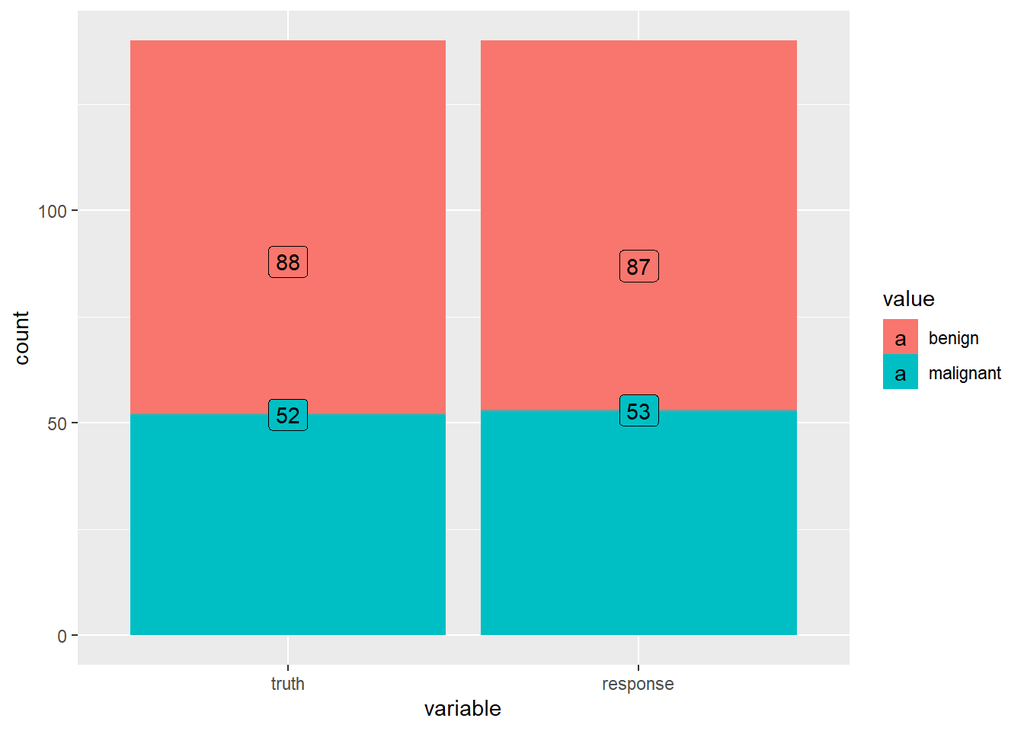

### BN - Bayesian Networks

#### Metoda 1

```
## INFO  [07:11:56.208] Applying learner 'classif.naive_bayes' on task 'breast_naomit' (iter 1/5)
## INFO  [07:11:56.263] Applying learner 'classif.naive_bayes' on task 'breast_naomit' (iter 2/5)
## INFO  [07:11:56.340] Applying learner 'classif.naive_bayes' on task 'breast_naomit' (iter 3/5)
## INFO  [07:11:56.407] Applying learner 'classif.naive_bayes' on task 'breast_naomit' (iter 4/5)
## INFO  [07:11:56.480] Applying learner 'classif.naive_bayes' on task 'breast_naomit' (iter 5/5)
```

```
##    row_id     truth  response  prob.benign prob.malignant
## 1:      1    benign malignant 9.787423e-23   1.000000e+00
## 2:      2    benign    benign 1.000000e+00   3.118450e-10
## 3:      3 malignant malignant 2.375423e-08   1.000000e+00
## 4:      4    benign    benign 1.000000e+00   5.287519e-10
## 5:      5 malignant malignant 5.734545e-38   1.000000e+00
## 6:      6 malignant malignant 1.819237e-76   1.000000e+00
```

```
##            truth
## response    benign malignant
##   benign        82         1
##   malignant      4        50
```

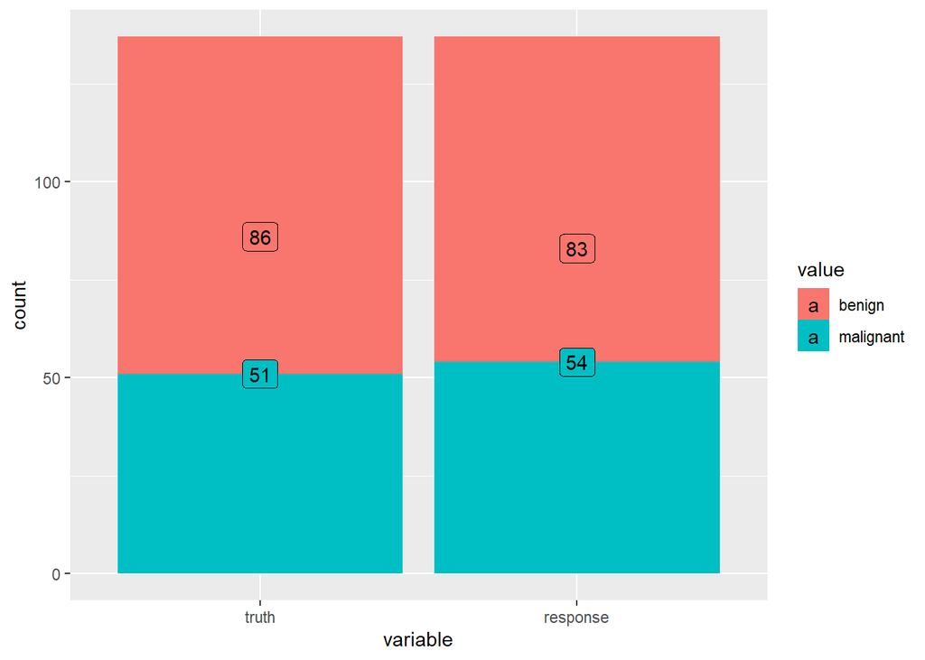

```
## INFO  [07:11:57.271] Applying learner 'classif.naive_bayes' on task 'breast_imp' (iter 1/5)
## INFO  [07:11:57.546] Applying learner 'classif.naive_bayes' on task 'breast_imp' (iter 2/5)
## INFO  [07:11:57.626] Applying learner 'classif.naive_bayes' on task 'breast_imp' (iter 3/5)
## INFO  [07:11:57.691] Applying learner 'classif.naive_bayes' on task 'breast_imp' (iter 4/5)
## INFO  [07:11:57.754] Applying learner 'classif.naive_bayes' on task 'breast_imp' (iter 5/5)
```

```
##    row_id     truth  response  prob.benign prob.malignant
## 1:      1    benign malignant 3.402768e-18   1.000000e+00
## 2:      2    benign    benign 1.000000e+00   5.112128e-10
## 3:      3 malignant malignant 4.083686e-17   1.000000e+00
## 4:      4 malignant malignant 1.148307e-05   9.999885e-01
## 5:      5    benign    benign 1.000000e+00   6.557709e-10
## 6:      6 malignant malignant 1.071489e-33   1.000000e+00
```

```
##            truth
## response    benign malignant
##   benign        84         1
##   malignant      4        51
```

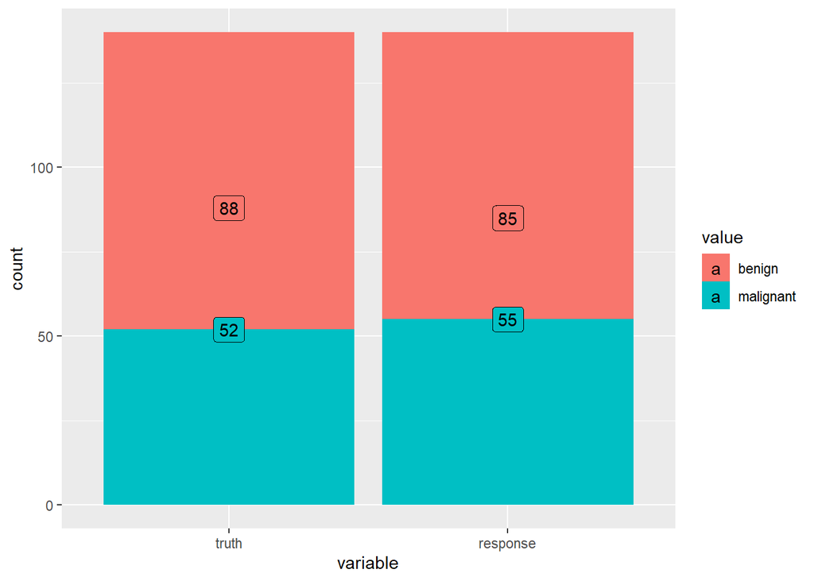

### LDA - Linear Discriminal Analysis

#### Metoda 1

```
## INFO  [07:11:58.512] Applying learner 'classif.lda' on task 'breast_naomit' (iter 1/5)
## INFO  [07:11:58.529] Applying learner 'classif.lda' on task 'breast_naomit' (iter 2/5)
## INFO  [07:11:58.577] Applying learner 'classif.lda' on task 'breast_naomit' (iter 3/5)
## INFO  [07:11:58.613] Applying learner 'classif.lda' on task 'breast_naomit' (iter 4/5)
## INFO  [07:11:58.645] Applying learner 'classif.lda' on task 'breast_naomit' (iter 5/5)
```

```
##    row_id     truth  response  prob.benign prob.malignant
## 1:      1    benign malignant 7.134721e-04   9.992865e-01
## 2:      2    benign    benign 9.999989e-01   1.142615e-06
## 3:      3 malignant malignant 1.584323e-01   8.415677e-01
## 4:      4    benign    benign 9.999999e-01   1.147832e-07
## 5:      5 malignant malignant 1.623370e-05   9.999838e-01
## 6:      6 malignant malignant 2.992803e-06   9.999970e-01
```

```
##            truth
## response    benign malignant
##   benign        84         4
##   malignant      2        47
```

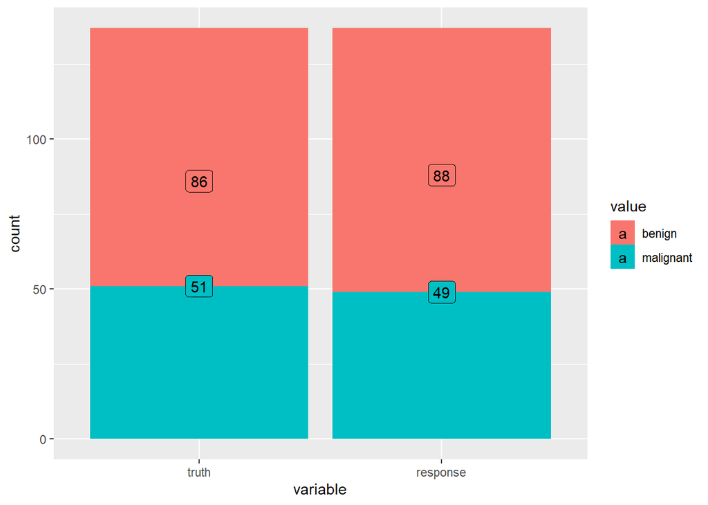

#### Metoda 2

```
## INFO  [07:11:59.310] Applying learner 'classif.lda' on task 'breast_imp' (iter 1/5)
## INFO  [07:11:59.340] Applying learner 'classif.lda' on task 'breast_imp' (iter 2/5)
## INFO  [07:11:59.373] Applying learner 'classif.lda' on task 'breast_imp' (iter 3/5)
## INFO  [07:11:59.402] Applying learner 'classif.lda' on task 'breast_imp' (iter 4/5)
## INFO  [07:11:59.432] Applying learner 'classif.lda' on task 'breast_imp' (iter 5/5)
```

```
##    row_id     truth  response  prob.benign prob.malignant
## 1:      1    benign malignant 2.202888e-03   9.977971e-01
## 2:      2    benign    benign 9.999970e-01   2.958818e-06
## 3:      3 malignant malignant 4.472388e-05   9.999553e-01
## 4:      4 malignant malignant 2.633652e-01   7.366348e-01
## 5:      5    benign    benign 9.999997e-01   3.300300e-07
## 6:      6 malignant malignant 3.032850e-05   9.999697e-01
```

```
##            truth
## response    benign malignant
##   benign        86         4
##   malignant      2        48
```

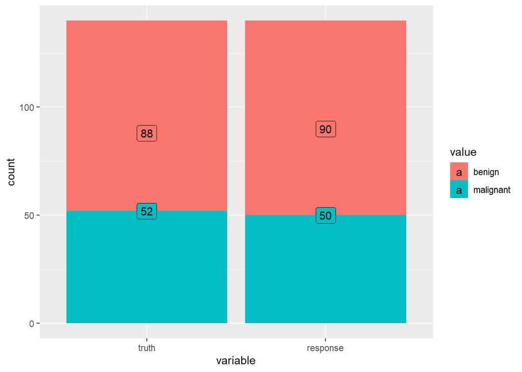

### RPART - Recursive Partitioning and Regression Trees

#### Metoda 1

```
## INFO  [07:12:00.155] Applying learner 'classif.rpart' on task 'breast_naomit' (iter 1/5)
## INFO  [07:12:00.193] Applying learner 'classif.rpart' on task 'breast_naomit' (iter 2/5)
## INFO  [07:12:00.223] Applying learner 'classif.rpart' on task 'breast_naomit' (iter 3/5)
## INFO  [07:12:00.254] Applying learner 'classif.rpart' on task 'breast_naomit' (iter 4/5)
## INFO  [07:12:00.286] Applying learner 'classif.rpart' on task 'breast_naomit' (iter 5/5)
```

```
##    row_id     truth  response prob.benign prob.malignant
## 1:      1    benign malignant  0.07486631     0.92513369
## 2:      2    benign    benign  0.98795181     0.01204819
## 3:      3 malignant    benign  0.98795181     0.01204819
## 4:      4    benign    benign  0.98795181     0.01204819
## 5:      5 malignant malignant  0.07486631     0.92513369
## 6:      6 malignant malignant  0.07486631     0.92513369
```

```
##            truth
## response    benign malignant
##   benign        80         1
##   malignant      6        50
```

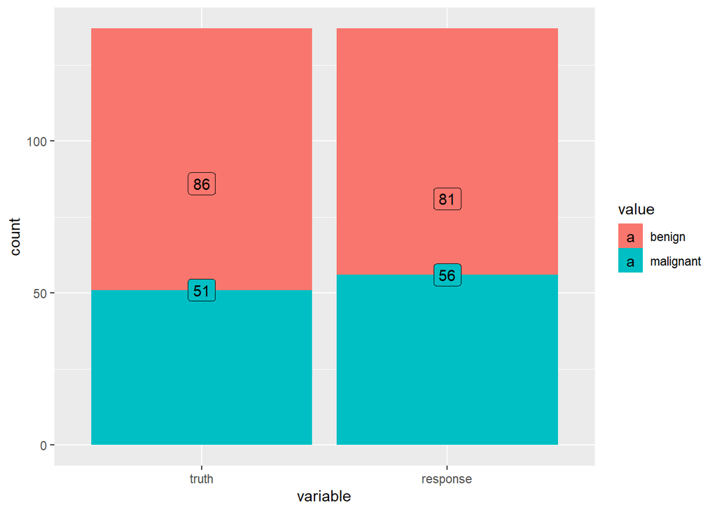

#### Metoda 2

```
## INFO  [07:12:01.171] Applying learner 'classif.rpart' on task 'breast_imp' (iter 1/5)
## INFO  [07:12:01.215] Applying learner 'classif.rpart' on task 'breast_imp' (iter 2/5)
## INFO  [07:12:01.245] Applying learner 'classif.rpart' on task 'breast_imp' (iter 3/5)
## INFO  [07:12:01.277] Applying learner 'classif.rpart' on task 'breast_imp' (iter 4/5)
## INFO  [07:12:01.305] Applying learner 'classif.rpart' on task 'breast_imp' (iter 5/5)
```

```
##    row_id     truth  response prob.benign prob.malignant
## 1:      1    benign malignant  0.05847953     0.94152047
## 2:      2    benign    benign  0.98826979     0.01173021
## 3:      3 malignant malignant  0.05847953     0.94152047
## 4:      4 malignant    benign  0.98826979     0.01173021
## 5:      5    benign    benign  0.98826979     0.01173021
## 6:      6 malignant malignant  0.05847953     0.94152047
```

```
##            truth
## response    benign malignant
##   benign        83         3
##   malignant      5        49
```

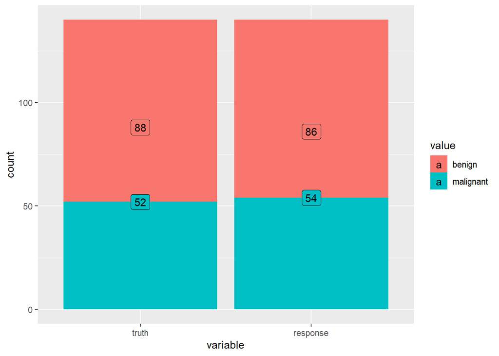

## Zestawienie powyższych metod

Do oceny wyników zastosujemy następujących miar:

- AUC
- Accuracy
- Precision
- Recall
- False Positive Rate - ta będzie dla nas szczególnie ważna, ponieważ oznacza dla nas % pacjentów, którzy mieli raka złośliwego (malignant), a zostali zakwalifikowani jako przypadek łagodny (benign). W pierwszej kolejności zależy nam, aby liczba takich przypadków była jak najmniejsza

### Wyniki kroswalidacji

| method | AUC | ACCURACY | PRECISION | RECALL | FalsePositiveRate | FalsePositive |
| --- | --- | --- | --- | --- | --- | --- |
| BN1 | 0.9892532 | 0.9578315 | 0.9852132 | 0.9491645 | 0.0250226 | 1.0 |
| BN2 | 0.9904241 | 0.9570946 | 0.9834845 | 0.9508721 | 0.0325364 | 1.2 |
| RF2 | 0.9926948 | 0.9677445 | 0.9804724 | 0.9689061 | 0.0367763 | 1.4 |
| SVM1 | 0.9965317 | 0.9707089 | 0.9774633 | 0.9782411 | 0.0419563 | 1.6 |
| RF1 | 0.9945480 | 0.9688574 | 0.9772393 | 0.9748851 | 0.0414392 | 1.6 |
| SVM2 | 0.9940386 | 0.9642053 | 0.9679771 | 0.9783944 | 0.0636001 | 2.4 |
| LDA1 | 0.9960830 | 0.9633528 | 0.9613260 | 0.9828542 | 0.0731759 | 2.8 |
| RPART1 | 0.9526885 | 0.9432360 | 0.9617394 | 0.9522380 | 0.0751961 | 2.8 |
| LDA2 | 0.9943937 | 0.9588642 | 0.9596284 | 0.9777564 | 0.0778119 | 3.0 |
| RPART2 | 0.9426028 | 0.9266088 | 0.9519391 | 0.9373826 | 0.1006863 | 3.6 |

### Wyniki predykcji

| method | AUC | ACCURACY | PRECISION | RECALL | FalsePositiveRate | FalsePositive |
| --- | --- | --- | --- | --- | --- | --- |
| BN1 | 0.9931601 | 0.9635036 | 0.9879518 | 0.9534884 | 0.0196078 | 1 |
| BN2 | 0.9934441 | 0.9642857 | 0.9882353 | 0.9545455 | 0.0192308 | 1 |
| RPART1 | 0.9541724 | 0.9489051 | 0.9876543 | 0.9302326 | 0.0196078 | 1 |
| RF1 | 0.9863201 | 0.9635036 | 0.9764706 | 0.9651163 | 0.0392157 | 2 |
| RF2 | 0.9877622 | 0.9642857 | 0.9770115 | 0.9659091 | 0.0384615 | 2 |
| SVM1 | 0.9895121 | 0.9489051 | 0.9647059 | 0.9534884 | 0.0588235 | 3 |
| SVM2 | 0.9901661 | 0.9500000 | 0.9655172 | 0.9545455 | 0.0576923 | 3 |
| RPART2 | 0.9570586 | 0.9428571 | 0.9651163 | 0.9431818 | 0.0576923 | 3 |
| LDA1 | 0.9917921 | 0.9562044 | 0.9545455 | 0.9767442 | 0.0784314 | 4 |
| LDA2 | 0.9921329 | 0.9571429 | 0.9555556 | 0.9772727 | 0.0769231 | 4 |

### Krzywe ROC

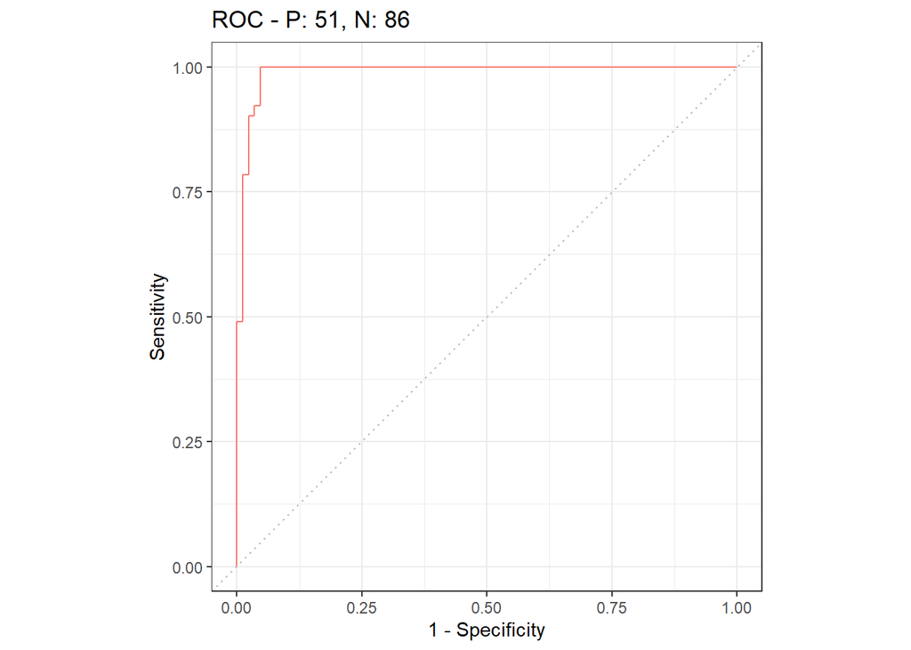